# cp2021-F03-Q7

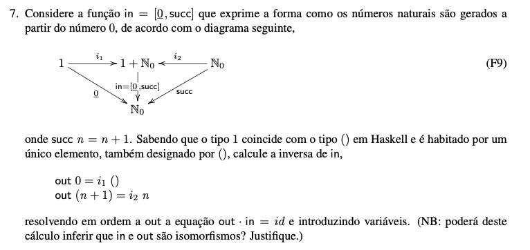

### Resolução

$ out \cdot in = id$

{ def. in $= [\underline{0}, succ ]$ }

$\equiv out \cdot [\underline{0}, succ ] = id$

{ reflexão-+, **lei (19)** }

$\equiv out \cdot [\underline{0}, succ ] = [i_1 , i_2]$

{ fusão-+, **lei (20)** }

$\equiv [out \cdot \underline{0}, out \cdot succ ] = [i_1 , i_2]$

{ eq-+, **lei (27)** }

$\equiv \begin{array}{lcl}out \cdot \underline{0} &=& i_1 \\ out \cdot succ &=& i_2\end{array}$

{ igualdade extensional, **lei (71)** }

$\equiv \begin{array}{lcl}(out \cdot \underline{0}) \ n &=& i_1 n\\ (out \cdot succ) \ n &=& i_2 \ n\end{array}$

{ **1** $= \{()\}$ }

$\equiv \begin{array}{lcl}(out \cdot \underline{0}) \ n &=& i_1 ()\\ (out \cdot succ) \ n &=& i_2 \ n\end{array}$

{ def-comp, **lei (72)** }

$\equiv \begin{array}{lcl}out \ (\underline{0} \ n) &=& i_1 ()\\ out \ (succ \ n) &=& i_2 \ n\end{array}$

{ def-const, **lei (74)**; def. $succ = n + 1$ }

$\equiv \begin{array}{lcl}out \ 0 &=& i_1 ()\\ out \ (n + 1) &=& i_2 \ n\end{array}$

### Conclusão

$in$ e $out$ são inversas uma da outra e, como tal, isomorfismos. Ambas transformam elementos de $1 + \mathbb{N}_0$ em elementos de $\mathbb{N}_0$ e vice-versa sem perda de informação.

### Haskell

```haskell
out 0 = Left ()
out n = Right (n-1)

-- type checking
:t out
```

out :: forall b. (Eq b, Num b) => b -> Either () b

```haskell
-- testing out with 3 and 0

out 3
out 0
```

```
Right 2
```

```
Left ()
```